## Richard Safran

### Student ID: 998862635

# Assignment 4

In this assignment, you'll combine the assignment 3 data set with nutrition data from the [USDA Food Composition Databases](https://ndb.nal.usda.gov/ndb/search/list). The CSV file `fresh.csv` contains the fresh fruits and vegetables data you extracted in assignment 3.

The USDA Food Composition Databases have a [documented](https://ndb.nal.usda.gov/ndb/doc/index) web API that returns data in JSON format . You need a key in order to use the API. Only 1000 requests are allowed per hour, so it would be a good idea to use [caching](https://pypi.python.org/pypi/requests-cache).

[Sign up for an API key here](https://api.data.gov/signup/). The key will work with any Data.gov API. You may need the key again later in the quarter, so make sure you save it.

These modules may be useful:

- [requests](http://docs.python-requests.org/en/master/user/quickstart/)
- [requests_cache](https://pypi.python.org/pypi/requests-cache)
- [urlparse](https://docs.python.org/2/library/urlparse.html)
- [pandas](http://pandas.pydata.org/pandas-docs/stable/)

```python
import requests_cache, requests
import pandas as pd
import urlparse
import numpy as np
import matplotlib.pyplot as plt
requests_cache.install_cache('coll_cache')
```

**Exercise 1.1.** Read the [search request documentation](https://ndb.nal.usda.gov/ndb/doc/apilist/API-SEARCH.md), then write a function called `ndb_search()` that makes a search request. The function should accept the search term as an argument. The function should return the search result items as a list (for 0 items, return an empty list).

Note that the search url is: `https://api.nal.usda.gov/ndb/search`

As an example, a search for `"quail eggs"` should return this list:

```
[{u'ds': u'BL',
  u'group': u'Branded Food Products Database',
  u'name': u'CHAOKOH, QUAIL EGG IN BRINE, UPC: 044738074186',
  u'ndbno': u'45094707',
  u'offset': 0},
 {u'ds': u'BL',
  u'group': u'Branded Food Products Database',
  u'name': u'L&W, QUAIL EGGS, UPC: 024072000256',
  u'ndbno': u'45094890',
  u'offset': 1},
 {u'ds': u'BL',
  u'group': u'Branded Food Products Database',
  u'name': u'BUDDHA, QUAIL EGGS IN BRINE, UPC: 761934535098',
  u'ndbno': u'45099560',
  u'offset': 2},
 {u'ds': u'BL',
  u'group': u'Branded Food Products Database',
  u'name': u'GRAN SABANA, QUAIL EGGS, UPC: 819140010103',
  u'ndbno': u'45169279',
  u'offset': 3},
 {u'ds': u'BL',
  u'group': u'Branded Food Products Database',
  u'name': u"D'ARTAGNAN, QUAIL EGGS, UPC: 736622102630",
  u'ndbno': u'45178254',
  u'offset': 4},
 {u'ds': u'SR',
  u'group': u'Dairy and Egg Products',
  u'name': u'Egg, quail, whole, fresh, raw',
  u'ndbno': u'01140',
  u'offset': 5}]
```

As usual, make sure you document and test your function.

```python
key = "kjt7vohPNzvT0WPrtJrCd8ALNNUO7LJ3XYShZWx6"
data_source_cat = ["Branded Food Products","Standard Reference"]
def ndb_search_url(search_term, data_source, max_per_page, key, offset = 0, verbose = False):
    """This function takes in a search term(str), the max amount of values to be returned (int) and the
    API key for data.gov(str). Then outputs the matching results in a json file."""

    #Determine the search specficiations for the API
    url = "https://api.nal.usda.gov/ndb/search"
    response = requests.get(url, params = {
            "q" : search_term,
            "format" : "json",
            "sort" : "r",
            "ds": data_source,
            "max" : max_per_page,
            "offset" : offset,
            "api_key" : key
        })
    response.raise_for_status() # check for errors
    if verbose:
        print response.url
    return response.json()[u'list'][u'item'] # parse JSON
quail_check = [ndb_search_url('quail eggs',data_source_cat[z],10,key) for z in range(2)] #Run the function for both the data source types
quail_check
```

```
[[{u'ds': u'BL',
   u'group': u'Branded Food Products Database',
   u'name': u'CHAOKOH, QUAIL EGG IN BRINE, UPC: 044738074186',
   u'ndbno': u'45094707',
   u'offset': 0},
  {u'ds': u'BL',
   u'group': u'Branded Food Products Database',
   u'name': u'L&W, QUAIL EGGS, UPC: 024072000256',
   u'ndbno': u'45094890',
   u'offset': 1},
  {u'ds': u'BL',
   u'group': u'Branded Food Products Database',
   u'name': u'BUDDHA, QUAIL EGGS IN BRINE, UPC: 761934535098',
   u'ndbno': u'45099560',
   u'offset': 2},
  {u'ds': u'BL',
   u'group': u'Branded Food Products Database',
   u'name': u'GRAN SABANA, QUAIL EGGS, UPC: 819140010103',
   u'ndbno': u'45169279',
   u'offset': 3},
  {u'ds': u'BL',
   u'group': u'Branded Food Products Database',
   u'name': u"D'ARTAGNAN, QUAIL EGGS, UPC: 736622102630",
   u'ndbno': u'45178254',
   u'offset': 4}],
 [{u'ds': u'SR',
   u'group': u'Dairy and Egg Products',
   u'name': u'Egg, quail, whole, fresh, raw',
   u'ndbno': u'01140',
   u'offset': 0}]]
```

**Exercise 1.2.** Use your search function to get NDB numbers for the foods in the `fresh.csv` file. It's okay if you don't get an NDB number for every food, but try to come up with a strategy that gets most of them. Discuss your strategy in a short paragraph.

Hints:

- The foods are all raw and unbranded.
- You can test search terms with the [online search page](https://ndb.nal.usda.gov/ndb/search/list).
- You can convert the output of `ndb_search()` to a data frame with `pd.DataFrame()`.
- The string methods for [Python](https://docs.python.org/2/library/stdtypes.html#string-methods) and [Pandas](http://pandas.pydata.org/pandas-docs/stable/text.html#method-summary) are useful here. It's okay if you use *simple* regular expressions in the Pandas methods, although this exercise can be solved without them.
- You can merge data frames that have a column in common with `pd.merge()`.

My strategy for acquiring the NDB numbers for the foods in fresh.csv consisted of the following steps:

1) Obtain the names for all of the food in the fresh.csv and place these into a list that would be easy to iterate across.

2) Create a function that took in a food name and plugged the food into the function from problem 1.1. This returned a json file with the most relevant information. Additionally, I found that isolating the values to only Standard Reference (ds = SR) got rid of brands, helping to narrow my search to unbranded.

3) After obtaining the json object from the function in problem 1.1 I then used if statements to screen all the n number of inputs. These checked for key phrases and classes such as there being raw present, no juice listed, and the class being either a fruit or a vegtable. I then found that the raw and unbranded food item in its original form tended to be the first value listed after meeting these specficiations. Therefore, I grabbed the first item in the json object and appeneded it to my final NDB json.

4) Next, I examined the missing elements and went back and adjusted the names for these food items to grab the appropriate NDB number. For instance, I changed kiwi to kiwifruit, adjusted _ to spaces, switched collard greens to collards, defined the varying types found in some items (like cabbage and cucumbers), and in some situations added raw to the name to ensure I got the right return value, seen in sweet potatoes becoming sweet potatoes,raw. Additionally, I expereimented with different return items in the json list for each food and found 20 a good number to capture the desired output without taking up an exuberent amount of computational capacity.

5) Lastly, I transformed my findings into a data frame. This resulted in me obtaining a NDB for every food item and each item being an appropriate classification. The only stretches are certain fruits with a large variety like oranges beings classified as naval oranges.

```python
food_data_path = pd.read_csv("/Users/Ricky/Desktop/STA 141b/HW/assignment 4/fresh.csv")
food_list = list(food_data_path['food'])
food_list_org = pd.DataFrame(food_data_path) #Preserve the original dataframe before I correct some of the terms

#Fix certain "problem foods" and adjust to their appropriate value. Used dictionaries to house changes that were not affected by any of the other changes in the dictionary.
dict_replace={
    'kiwi': 'kiwifruit',
    '_':' ',
}
change_list = list(dict_replace.iteritems())

#Iterate over each element of the food_list and then iterate over all the elements in the dictionary to check if they matched. If so replace the first element of the dictionary with the second element.
for food in range(len(food_list)):
    for item in range(len(change_list)):
        food_list[food] = food_list[food].replace(change_list[item][0],change_list[item][1])

#For changes affected by prior changes wrote a loop that changes the ith element of bad_terms with the ith element of the replace_terms.
bad_terms = ['collard greens','cucumbers','cucumbers','cabbage', 'cabbage', 'sweet potatoes']
replace_terms = ['collards', 'cucumbers, with peel', 'cucumbers, peeled', 'cabbage,raw','cabbage, red', 'sweet potatoes,raw']
for term in range(len(bad_terms)):
    food_list[food_list.index(bad_terms[term])] = food_list[food_list.index(bad_terms[term])].replace(bad_terms[term],replace_terms[term])

final_food_list = []
def list_food_raw(food): #Function that uses the function from question 1 to grab all the numbers of the IDs for the food from the list above.
    """
    Function takes in a food and returns the top 20 refrences that most closely resemble the food. From these 20 refrences
    the function next sorts down the 20 refrences to those that contain the word raw, don't contain the name juice, and
    that belong to either the fruit or vegetables category. Last, I appeneded the first remaining value to the data frame
    and then broke out of the function.
    """
    food_json = ndb_search_url(food,"Standard Reference",20,key)

    for x in range(len(food_json)):
        if (food_json[x][u'name'].find("raw") != -1) == True and (food_json[x][u'name'].find("juice") == -1) == True:
            if (food_json[x][u'group'] == u'Fruits and Fruit Juices') == True or (food_json[x][u'group'] == u'Vegetables and Vegetable Products') == True:
                final_food_list.append(food_json[x])
                return final_food_list
                break

for item in range(len(food_list)):
    """
    Loop over all elements of the food list to run through the function. Returns a single json file with 49 seperate elements
    that correspond to the raw number identification for that food.
    """
    json_final_file = list_food_raw(food_list[item])

NDB_df = pd.DataFrame(json_final_file) #Data frame from function with ndbno
final_df = food_list_org.join(NDB_df['ndbno']).join(NDB_df['name']) #combine ndbno and classification with the original dataframe from the csv file
final_df.head()
```

|  | form | price_per_lb | yield | lb_per_cup | price_per_cup | food | type | ndbno | name |
| --- | --- | --- | --- | --- | --- | --- | --- | --- | --- |
| 0 | Fresh1 | 0.333412 | 0.52 | 0.330693 | 0.212033 | watermelon | fruit | 09326 | Watermelon, raw |
| 1 | Fresh1 | 0.535874 | 0.51 | 0.374786 | 0.393800 | cantaloupe | fruit | 09181 | Melons, cantaloupe, raw |
| 2 | Fresh1 | 1.377962 | 0.74 | 0.407855 | 0.759471 | tangerines | fruit | 09218 | Tangerines, (mandarin oranges), raw |
| 3 | Fresh1 | 2.358808 | 0.94 | 0.319670 | 0.802171 | strawberries | fruit | 09316 | Strawberries, raw |
| 4 | Fresh1 | 1.827416 | 0.94 | 0.363763 | 0.707176 | plums | fruit | 09279 | Plums, raw |

**Exercise 1.3.** Read the [food reports V2 documentation](https://ndb.nal.usda.gov/ndb/doc/apilist/API-FOOD-REPORTV2.md), then write a function called `ndb_report()` that requests a *basic* food report. The function should accept the NDB number as an argument and return the list of nutrients for the food.

Note that the report url is: `https://api.nal.usda.gov/ndb/V2/reports`

For example, for `"09279"` (raw plums) the first element of the returned list should be:

```
{u'group': u'Proximates',
 u'measures': [{u'eqv': 165.0,
   u'eunit': u'g',
   u'label': u'cup, sliced',
   u'qty': 1.0,
   u'value': u'143.93'},
  {u'eqv': 66.0,
   u'eunit': u'g',
   u'label': u'fruit (2-1/8" dia)',
   u'qty': 1.0,
   u'value': u'57.57'},
  {u'eqv': 151.0,
   u'eunit': u'g',
   u'label': u'NLEA serving',
   u'qty': 1.0,
   u'value': u'131.72'}],
 u'name': u'Water',
 u'nutrient_id': u'255',
 u'unit': u'g',
 u'value': u'87.23'}
```

Be sure to document and test your function.

```python
nutrition_list = [] #Initialize a list to house all the nutrient information

def ndb_report(NDB, verbose = False):
    """
    Function takes in a NDB code and returns the json portion that captures the nutrients for that food. Data is returned
    with the basic parameter in a json format. API key for data.gov needed.
    """
    url_ndb = "https://api.nal.usda.gov/ndb/V2/reports"
    response_ndb = requests.get(url_ndb, params = {
            "ndbno" : NDB,
            "format" : "json",
            "type" : "b",
            "api_key" : key
        })
    response_ndb.raise_for_status() # check for errors
    if verbose:
        print response_ndb.url
    return response_ndb.json()[u'foods'][0][u'food'][u'nutrients'] # parse JSON

plum_check = ndb_report('09279') #Verify output matches plum output above, which it does

NDB_df['ndbno'] = NDB_df['ndbno'].apply(str) #Change the column in the NDB database to a string instead of unicode.
for code in range(len(NDB_df['ndbno'])):
    """
    Loop over all elements of the NDB column from 1.2's output to run through the function. Returns a single json file
    with 49 seperate elements that correspond to the nutrient information for a food.
    """
    nutrition_list.append(ndb_report(NDB_df['ndbno'][code]))
plum_check[0]
```

```
{u'group': u'Proximates',
 u'measures': [{u'eqv': 165.0,
   u'eunit': u'g',
   u'label': u'cup, sliced',
   u'qty': 1.0,
   u'value': u'143.93'},
  {u'eqv': 66.0,
   u'eunit': u'g',
   u'label': u'fruit (2-1/8" dia)',
   u'qty': 1.0,
   u'value': u'57.57'},
  {u'eqv': 151.0,
   u'eunit': u'g',
   u'label': u'NLEA serving',
   u'qty': 1.0,
   u'value': u'131.72'}],
 u'name': u'Water',
 u'nutrient_id': u'255',
 u'unit': u'g',
 u'value': u'87.23'}
```

**Exercise 1.4.** Which foods provide the best combination of price, yield, and nutrition? You can use kilocalories as a measure of "nutrition" here, but more a detailed analysis is better. Use plots to support your analysis.

To determine which food was the best combination of price, yield and nutrition I first created a criteria for nutrition. The end criteria examined the kilocalories found in each food where more kilocalories corresponded to a positive effect. This paramater resulted in two ways to interpret the results, the price paid for each additional kcal or the amount of kcals recieved for each dollar, that yielded the same results due to these being a ratio. Based on my findings I discovered that the most cost effective foods were:

```
1) Potatoes
2) Bananas
3) Sweet potatoes
4) Avocados
5) Watermelon
```

Next I wanted to determine whether kcals were different across frutis and vegtables. To answer this question I created a box plot with fruits and vegtables seperated. Based on the graph I can conclude that fruits on avg are a more efficient buy since they yield approximately an extra 50 kcal per every dollar. However, the highest energy containing vegtables yield the most kcal out of any food, being potatoes at number 1, sweet potatoes at number 3, and avocados at number 4. Thus, while fruits would be a better purchase if the food inside the group was selected randomly, the upper outliers in the vegtable group results in 3 of the 4 most efficient foods being vegtables.

After just looking at kcal I was interested in examining some extra variables. Therefore, I created a dataframe with all 33 nutrients registered for all of the 49 food items. I was interested in how fiber was related to kcal efficiency, and price overall, especially across the differnt food groups. Therefore, I created a scatter plot that had price per cup on the x axiss, kcal per pound on the y axis, fiber per 100 g as the size of the dots, and color representing the different food groups. This resulted in a small trend where the cheaper the food the lest kcal and fiber present. As the price increased this trend continued but at a lesser degree. Therefore, there is potential heteroskedasicity in the data. It was interesting that every food item except one was underneath 450 kcal per lb as a flat distribution. Fiber also does not appear to be closely tied to the other variables. This could possibly signify price not being closely tied to kcal but instead possibly fat content, nutrients, growth conditions, or rarity of the food.

Graphs for each of the paragraphs can be found below in the order they are mentioned above.

```python
#33 different nutritional parameters that were grabbed if they contained the unit kcal.
nutrition_list_kcal = []
for s in range(len(food_list)):
    """
    Iterate across all of the 49 food items.
    """
    for r in range(len(nutrition_list[s])):
        """
        Iterate across all of the 33 nutrients
        """
        if (nutrition_list[s][r][u'unit'].encode('ascii','ignore') == 'kcal') == True:
            value = int(nutrition_list[s][r][u'value'].encode('ascii','ignore'))*4.5359237 #convert kcal per 100 g to kcal per lb
            name = final_df['name'][s] #Obtain the list of names to provide a name to each of the kcal values
            nutrition_list_kcal.append([name, value]) #Attach the names to the kcal.
kcal_df = pd.DataFrame(nutrition_list_kcal, columns = ['name', 'kcal_per_lb']) #Create a dataframe with the kcal_per_lb and the name of the food.
final_df = pd.merge(final_df,kcal_df,on = 'name') #Merge with the main data frame.
final_df.head()
```

|  | form | price_per_lb | yield | lb_per_cup | price_per_cup | food | type | ndbno | name | kcal_per_lb |
| --- | --- | --- | --- | --- | --- | --- | --- | --- | --- | --- |
| 0 | Fresh1 | 0.333412 | 0.52 | 0.330693 | 0.212033 | watermelon | fruit | 09326 | Watermelon, raw | 136.077711 |
| 1 | Fresh1 | 0.535874 | 0.51 | 0.374786 | 0.393800 | cantaloupe | fruit | 09181 | Melons, cantaloupe, raw | 154.221406 |
| 2 | Fresh1 | 1.377962 | 0.74 | 0.407855 | 0.759471 | tangerines | fruit | 09218 | Tangerines, (mandarin oranges), raw | 240.403956 |
| 3 | Fresh1 | 2.358808 | 0.94 | 0.319670 | 0.802171 | strawberries | fruit | 09316 | Strawberries, raw | 145.149558 |
| 4 | Fresh1 | 1.827416 | 0.94 | 0.363763 | 0.707176 | plums | fruit | 09279 | Plums, raw | 208.652490 |

```python
#Append new cols for the main dataframe where I standardize kcal with price and yield
final_df['price_per_kcal'] = (final_df['price_per_lb']/final_df['kcal_per_lb'])/final_df['yield']
final_df['kcal_per_dollar'] = (final_df['kcal_per_lb']/final_df['price_per_lb'])*final_df['yield']
final_df['food'] = food_list #Update the food column with my correct food names
final_df.head()
```

|  | form | price_per_lb | yield | lb_per_cup | price_per_cup | food | type | ndbno | name | kcal_per_lb | price_per_kcal | kcal_per_dollar |
| --- | --- | --- | --- | --- | --- | --- | --- | --- | --- | --- | --- | --- |
| 0 | Fresh1 | 0.333412 | 0.52 | 0.330693 | 0.212033 | watermelon | fruit | 09326 | Watermelon, raw | 136.077711 | 0.004712 | 212.231120 |
| 1 | Fresh1 | 0.535874 | 0.51 | 0.374786 | 0.393800 | cantaloupe | fruit | 09181 | Melons, cantaloupe, raw | 154.221406 | 0.006813 | 146.775081 |
| 2 | Fresh1 | 1.377962 | 0.74 | 0.407855 | 0.759471 | tangerines | fruit | 09218 | Tangerines, (mandarin oranges), raw | 240.403956 | 0.007746 | 129.102939 |
| 3 | Fresh1 | 2.358808 | 0.94 | 0.319670 | 0.802171 | strawberries | fruit | 09316 | Strawberries, raw | 145.149558 | 0.017288 | 57.843011 |
| 4 | Fresh1 | 1.827416 | 0.94 | 0.363763 | 0.707176 | plums | fruit | 09279 | Plums, raw | 208.652490 | 0.009317 | 107.328238 |

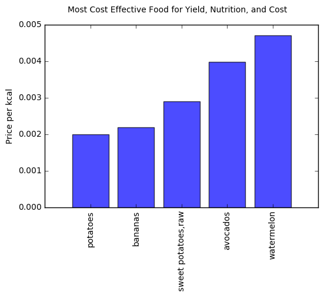

```python
graph_df = final_df.set_index(['food'])

#Want the lowest price for each kcal since want to minimize price for each kcal of energy
sort_cheap_price_per_kcal = graph_df.sort_values('price_per_kcal', ascending=True)
cheapest_price_per_kcal = graph_df.sort_values('price_per_kcal', ascending=True).head(5)

#Set up the x axis values with names saved to a list and a position for the inital graph.
objects = cheapest_price_per_kcal.index.values.tolist()
y_pos = np.arange(len(objects))

#Plot the data
plt.bar(y_pos, cheapest_price_per_kcal['price_per_kcal'], align='center', alpha=0.7)

#Set up the graphs
plt.xticks(y_pos, objects, rotation = 'vertical')
plt.ylabel('Price per kcal')
plt.suptitle('Most Cost Effective Food for Yield, Nutrition, and Cost')
plt.show()
```

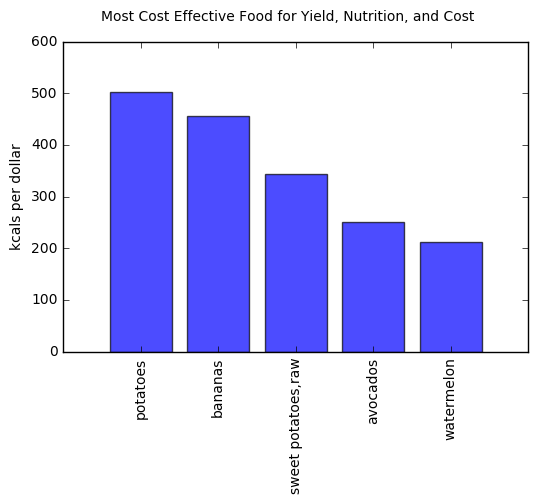

```python
#Want the most kcal per dollar so find top 5 values
sort_cheap_kcal_per_dollar = graph_df.sort_values('kcal_per_dollar', ascending=False)
cheapest_kcals_per_dollar = graph_df.sort_values('kcal_per_dollar', ascending=False).head(5)

#Set up the x axis values with names saved to a list and a position for the inital graph.
objects1 = cheapest_price_per_kcal.index.values.tolist()
y_pos1 = np.arange(len(objects1))

#Plot the data
plt.bar(y_pos1, cheapest_kcals_per_dollar['kcal_per_dollar'], align='center', alpha=0.7)

#Set up the graphs
plt.xticks(y_pos1, objects1, rotation = 'vertical')
plt.ylabel('kcals per dollar')
plt.suptitle('Most Cost Effective Food for Yield, Nutrition, and Cost')
plt.show()
```

```python
nutrition_name = []
nutrient_list_comp = []
for r in range(len(nutrition_list[0])):
    """
    Iterate across all 33 elements in the nutrition list. Grabs the nurtrient name and the unit of measure for that name.
    """
    nutrient_name = nutrition_list[0][r][u'name'].encode('ascii','ignore')
    measure_nutrient_name = nutrition_list[0][r][u'unit'].encode('ascii','ignore')
    nutrients_info = [nutrient_name, measure_nutrient_name]
    nutrition_name.append(nutrients_info)

for s in range(len(food_list)):
    """
    Iterate across all 49 elements in the food list and for each item build a row with all 33 nutrients. Then append each
    row to get a data frame for all 49 food items with all of the nutritional information present.
    """
    nutrient_data = []
    nutrient_names = []
    for r in range(len(nutrition_list[s])):
        nutrient_name = nutrition_list[0][r][u'name'].encode('ascii','ignore') #Acquire the name of the nutrient
        measure_nutrient_name = nutrition_list[0][r][u'unit'].encode('ascii','ignore') #Acquire the unit of measure for the nutrient
        column_nutrients = (nutrient_name+" "+measure_nutrient_name) #Put the name and unit of measure together
        nutrient_names.append(column_nutrients) #Append name and unit to a list
        value_nutrients = float(nutrition_list[s][r][u'value'].encode('ascii','ignore')) #Find the value for the corresponding nutrient and item
        nutrient_data.extend([value_nutrients]) #Keep adding the value on to a list
    nutrient_list_comp.append(nutrient_data) #Append the whole row to a list in the form of a list

nutrient_df = pd.DataFrame(nutrient_list_comp, columns = [n for n in nutrient_names]) #Create a data frame with the nutrients
nutrient_df = pd.DataFrame(food_list, columns = ["food"]).join(nutrient_df) #Make another data frame with the food names and append the values on to it.
nutrient_df_comp = nutrient_df.set_index(["food"]) #Set the food as the index.
final_df_nutrients = pd.merge(final_df,nutrient_df, on = 'food') #Merge on to the original df.
nutrient_df_comp.head() #Waht the nutrient df looks like
```

| food | Water g | Energy kcal | Protein g | Total lipid (fat) g | Carbohydrate, by difference g | Fiber, total dietary g | Sugars, total g | Calcium, Ca mg | Iron, Fe mg | Magnesium, Mg mg | ... | Vitamin E (alpha-tocopherol) mg | Vitamin D (D2 + D3) g | Vitamin D IU | Vitamin K (phylloquinone) g | Fatty acids, total saturated g | Fatty acids, total monounsaturated g | Fatty acids, total polyunsaturated g | Fatty acids, total trans g | Cholesterol mg | Caffeine mg |
| --- | --- | --- | --- | --- | --- | --- | --- | --- | --- | --- | --- | --- | --- | --- | --- | --- | --- | --- | --- | --- | --- |
| watermelon | 91.45 | 30.0 | 0.61 | 0.15 | 7.55 | 0.4 | 6.20 | 7.0 | 0.24 | 10.0 | ... | 0.05 | 0.0 | 0.0 | 0.1 | 0.016 | 0.037 | 0.050 | 0.0 | 0.0 | 0.0 |
| cantaloupe | 90.15 | 34.0 | 0.84 | 0.19 | 8.16 | 0.9 | 7.86 | 9.0 | 0.21 | 12.0 | ... | 0.05 | 0.0 | 0.0 | 2.5 | 0.051 | 0.003 | 0.081 | 0.0 | 0.0 | 0.0 |
| tangerines | 85.17 | 53.0 | 0.81 | 0.31 | 13.34 | 1.8 | 10.58 | 37.0 | 0.15 | 12.0 | ... | 0.20 | 0.0 | 0.0 | 0.0 | 0.039 | 0.060 | 0.065 | 0.0 | 0.0 | 0.0 |
| strawberries | 90.95 | 32.0 | 0.67 | 0.30 | 7.68 | 2.0 | 4.89 | 16.0 | 0.41 | 13.0 | ... | 0.29 | 0.0 | 0.0 | 2.2 | 0.015 | 0.043 | 0.155 | 0.0 | 0.0 | 0.0 |
| plums | 87.23 | 46.0 | 0.70 | 0.28 | 11.42 | 1.4 | 9.92 | 6.0 | 0.17 | 7.0 | ... | 0.26 | 0.0 | 0.0 | 6.4 | 0.017 | 0.134 | 0.044 | 0.0 | 0.0 | 0.0 |

5 rows × 33 columns

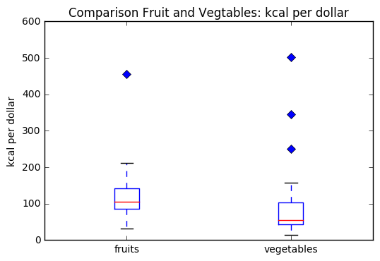

```python
#Creating a boxplot comparing fruits and vegtables kcal per dollar
fruits = final_df[final_df['type'] == 'fruit']
veggies = final_df[final_df['type'] == 'vegetables']
x_labels = ['fruits','vegetables']
pos = np.arange(len(x_labels))+1

plt.boxplot([fruits['kcal_per_dollar'],veggies['kcal_per_dollar']], 0, 'gD')
plt.ylabel('kcal per dollar')
plt.xticks(pos, x_labels)
plt.title('Comparison Fruit and Vegtables: kcal per dollar')
plt.show()
```

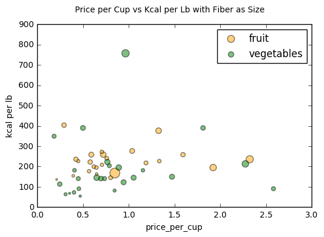

```python
#Isolate the type of food so to assign different colors and make a lengend with colors shaded in.
fruits_df = final_df_nutrients[final_df_nutrients["type"] =="fruit"]
vegetables_df = final_df_nutrients[final_df_nutrients["type"] =="vegetables"]
use_colours = {"fruit": "orange", "vegetables": "green"}

#Plot comparing 4 variables. X axis is price per cup, Y axis is Kcal per lb, color is type of food, and size is fiber.
plt.scatter(fruits_df["price_per_cup"], fruits_df["kcal_per_lb"], c = use_colours["fruit"], s=fruits_df["Fiber, total dietary g"]*12, alpha=0.5, label = "fruit")
plt.scatter(vegetables_df["price_per_cup"], vegetables_df["kcal_per_lb"], c=use_colours["vegetables"], s=vegetables_df["Fiber, total dietary g"]*12, alpha=0.5, label = "vegetables")
plt.ylabel("kcal per lb")
plt.xlabel("price_per_cup")
plt.suptitle("Price per Cup vs Kcal per Lb with Fiber as Size")
plt.legend(scatterpoints = 1)
plt.show()
```